# 3.4 The coordinate reference system: Why it matters and how to use it

Which sampling sites fall within a protected area? How far has an invasive species spread? Our answers depend on locations being represented accurately. A **coordinate reference system** (CRS) is the reference system that allows us to define the location of a geometry on the surface of the Earth. Without a CRS, -77.05 and 38.89 could describe degrees of longitude and latitude, meters east and north of some origin, or something else entirely. In *3.2 Introduction to spatial vector data*, we transformed spatial data to a different CRS as a pre-processing step.

In completing this lesson, you will learn how to:

- Describe the components of geodetic and projected coordinate reference systems
- Read the well-known text representation of a CRS with `st_crs()`
- Transform coordinates with `st_transform()`, and distinguish transformation from assigning a CRS
- Choose a CRS that is appropriate for a given task

**Important!** Before starting this tutorial, be sure that you have completed all preliminary and previous lessons!

## Data for this lesson

In this lesson, we will explore:

**dc_census.geojson**: A polygon shapefile of census tracts in the District of Columbia. The data are in a projected coordinate system (datum = WGS84, projection is UTM, Zone 18N) with the EPSG code 32618.

The data include the following fields:

- GEOID, character: The **primary key** for each census tract.
- STATEFP, character: A **foreign key** to the US state in the states data.
- ALAND, numeric: The area covered by land in each census tract, in square meters.
- AWATER, numeric: The area covered by water in each census tract, in square meters.
- INCOME, numeric: The median income of each census tract.
- POPULATION, numeric: The total population of each census tract.

**sites.csv**: Locations of Neighborhood Nestwatch sampling sites, provided as a tabular dataset. Locations were recorded with a handheld GPS unit set to the unprojected Coordinate Reference System (CRS) with the datum WGS84 and EPSG code 4326.

The data include the following variables:

- site, character: The **primary key** for each site, which here is a fruit name assigned to each site.
- lon, numeric: The longitudinal coordinates of each site, in decimal degrees.
- lat, numeric: The latitudinal coordinates of each site, in decimal degrees.

The data include the following fields:

- GEOID, character: The **primary key** for each state.
- NAME, character: The name of each state.
- REGION, character: The region of the United States where each state is located.
- AREA, numeric: The total area of each state, in square kilometers.
- ttl__10, numeric: The total population of each state in 2010.
- ttl__15, numeric: The total population of each state in 2015.

## Set up your session

Please complete the following to ensure that you are working in a clean session:

1. Please ensure that your **Global Environment** is empty.
2. In the *History* tab of your **workspace pane**, ensure that your **session history** is empty.

Now that we are working in a clean session:

1. Create a script file.
2. Save your script file as `scripts/coordinate_reference_systems.R`.
3. Add metadata as a comment on the top of the file.
4. Following your metadata, create a new **code section** and call it “`setup`”.
5. Following your section header, attach the *sf* package and the packages that comprise the **core tidyverse**, then run `source_script_module_3.R` (see *3.2 Introduction to spatial vector data*).

At this point, your script should look something like:

```r
# My code for the coordinate reference systems tutorial

# setup --------------------------------------------------------

library(sf)
library(tidyverse)

# Load the source script:

source("scripts/source_script_module_3.R")
```

Next, we will read in and pre-process the data for this lesson. Let’s start with a “Now you!” challenge:

Now you!

In a single piped statement:

- Read in the shapefile `states.shp`
- Clean the field names with `clean_names()`
- Subset the fields to `name`, renaming the field to `state`
- Assign the name `states` to the resultant object in your global environment.

*Hint: We read and pre-processed shapefiles in this way in **3.2 Introduction to spatial vector data**.*

Click here to see my answer

```r
states <-

  # Read in the shapefile:

  st_read(
    "data/raw/shapefiles/states.shp",
    quiet = TRUE
  ) %>%

  # Clean the field names:

  clean_names() %>%

  # Subset to the field of interest and rename:

  select(state = name)
```

We will also use a GeoJSON file of census tracts in the District of Columbia. Here, `census` refers to the projected DC dataset, not the larger `census.shp` dataset from 3.2:

```r
# Read in and pre-process DC census data:

census <-
  st_read(
    "data/raw/shapefiles/dc_census.geojson",
    quiet = TRUE
  ) %>%
  clean_names() %>%
  select(
    geoid,
    income,
    population
  )
```

… and a tabular dataset of Neighborhood Nestwatch sampling sites:

```r
# Read in the site locations:

sites <-
  read_csv("data/raw/sites.csv")
```

## The components of a CRS

A CRS locates a geometry on the surface of the Earth with a set of components:

- A **datum**, which anchors a model of the Earth’s shape (a reference ellipsoid) to the Earth
- A coordinate system, which defines the axes along which coordinates are measured and the units of those coordinates
- For some coordinate reference systems, a **projection**, which is a mathematical transformation from coordinates on a curved reference surface to coordinates on a flat map.

We work with two kinds of CRS in this course. A **geographic** CRS records longitude and latitude in angular units, usually decimal degrees. The *sf* package labels these as **geodetic** in its printed output, so we use that term here. A **projected** CRS records locations on a flat coordinate grid in linear units, typically meters.

Both kinds are present in our data for this lesson. Please highlight and run `states`:

```
Simple feature collection with 49 features and 1 field
Geometry type: MULTIPOLYGON
Dimension:     XY
Bounding box:  xmin: -124.7042 ymin: 24.55868 xmax: -66.9824 ymax: 49.38436
Geodetic CRS:  NAD83
First 10 features:
         state                       geometry
1      Alabama MULTIPOLYGON (((-88.20006 3...
2      Arizona MULTIPOLYGON (((-114.7196 3...
3     Colorado MULTIPOLYGON (((-109.0501 4...
4  Connecticut MULTIPOLYGON (((-73.48731 4...
5      Florida MULTIPOLYGON (((-81.81169 2...
6      Georgia MULTIPOLYGON (((-85.60516 3...
7        Idaho MULTIPOLYGON (((-116.916 45...
8      Indiana MULTIPOLYGON (((-87.52404 4...
9       Kansas MULTIPOLYGON (((-102.0517 4...
10   Louisiana MULTIPOLYGON (((-92.01783 2...
```

The metadata line `Geodetic CRS: NAD83` reports the kind of CRS and its name. Now please highlight and run `census`:

```
Simple feature collection with 179 features and 3 fields
Geometry type: POLYGON
Dimension:     XY
Bounding box:  xmin: 316267.9 ymin: 4295630 xmax: 334406.7 ymax: 4318297
Projected CRS: WGS 84 / UTM zone 18N
First 10 features:
         geoid income population                       geometry
1  11001010900  32143       3470 POLYGON ((322920 4296613, 3...
2  11001010400  40025       4368 POLYGON ((325619.8 4300849,...
3  11001009903  55665       1319 POLYGON ((332607.6 4306320,...
4  11001009904  37083       1508 POLYGON ((332102.5 4305903,...
5  11001000902 184583       2302 POLYGON ((316268.6 4311628,...
6  11001001500 193233       6066 POLYGON ((320533 4315687, 3...
7  11001001302  84758       7635 POLYGON ((320990 4313023, 3...
8  11001005500  97596       6651 POLYGON ((321720.6 4308195,...
9  11001000801 120313       7064 POLYGON ((317488.9 4309700,...
10 11001009905  37256       2510 POLYGON ((332649.8 4305315,...
```

Here, the line reads `Projected CRS: WGS 84 / UTM zone 18N`. The bounding box of `states` is expressed in decimal degrees, whereas that of `census` is expressed in meters.

Check your understanding

True or false: A projected CRS expresses locations in angular units, usually decimal degrees.

The bounding box of a simple features object spans values from roughly 300,000 to 330,000 along the X axis. What should you do before interpreting those values?

Check the CRS and its units with st_crs() Assume the values are meters because they are large Assign EPSG 4326 without consulting the metadata Divide by 1,000 to convert the values to degrees

## Read a CRS

The complete description is written in **well-known text** (WKT), the international standard for representing coordinate reference systems. We print it with `st_crs()` (see *3.2 Introduction to spatial vector data*).

### The WKT of a geodetic CRS

Let’s read the CRS of `states`:

```r
st_crs(states)
```

```
Coordinate Reference System:
  User input: NAD83
  wkt:
GEOGCRS["NAD83",
    DATUM["North American Datum 1983",
        ELLIPSOID["GRS 1980",6378137,298.257222101,
            LENGTHUNIT["metre",1]]],
    PRIMEM["Greenwich",0,
        ANGLEUNIT["degree",0.0174532925199433]],
    CS[ellipsoidal,2],
        AXIS["latitude",north,
            ORDER[1],
            ANGLEUNIT["degree",0.0174532925199433]],
        AXIS["longitude",east,
            ORDER[2],
            ANGLEUNIT["degree",0.0174532925199433]],
    ID["EPSG",4269]]
```

The WKT is organized as a set of nested bracketed sections. For a geodetic CRS:

- `GEOGCRS` names the CRS (“NAD83”)
- `DATUM` and `ELLIPSOID` describe the model of the Earth’s surface. Here, 6378137 is the model’s equatorial radius in meters
- `PRIMEM` defines the **prime meridian**, which is the location of 0° longitude
- `CS` and `AXIS` define the latitude and longitude axes. `ANGLEUNIT` states that both use degrees
- The final, outermost `ID` provides the EPSG code of the CRS. Other `ID` entries identify individual components.

*Note: Although this WKT lists latitude before longitude, supply X then Y (longitude, latitude) in the sf examples here.*

### The WKT of a projected CRS

Now let’s read the CRS of `census`:

```r
st_crs(census)
```

```
Coordinate Reference System:
  User input: WGS 84 / UTM zone 18N
  wkt:
PROJCRS["WGS 84 / UTM zone 18N",
    BASEGEOGCRS["WGS 84",
        ENSEMBLE["World Geodetic System 1984 ensemble",
            MEMBER["World Geodetic System 1984 (Transit)"],
            MEMBER["World Geodetic System 1984 (G730)"],
            MEMBER["World Geodetic System 1984 (G873)"],
            MEMBER["World Geodetic System 1984 (G1150)"],
            MEMBER["World Geodetic System 1984 (G1674)"],
            MEMBER["World Geodetic System 1984 (G1762)"],
            MEMBER["World Geodetic System 1984 (G2139)"],
            MEMBER["World Geodetic System 1984 (G2296)"],
            ELLIPSOID["WGS 84",6378137,298.257223563,
                LENGTHUNIT["metre",1]],
            ENSEMBLEACCURACY[2.0]],
        PRIMEM["Greenwich",0,
            ANGLEUNIT["degree",0.0174532925199433]],
        ID["EPSG",4326]],
    CONVERSION["UTM zone 18N",
        METHOD["Transverse Mercator",
            ID["EPSG",9807]],
        PARAMETER["Latitude of natural origin",0,
            ANGLEUNIT["degree",0.0174532925199433],
            ID["EPSG",8801]],
        PARAMETER["Longitude of natural origin",-75,
            ANGLEUNIT["degree",0.0174532925199433],
            ID["EPSG",8802]],
        PARAMETER["Scale factor at natural origin",0.9996,
            SCALEUNIT["unity",1],
            ID["EPSG",8805]],
        PARAMETER["False easting",500000,
            LENGTHUNIT["metre",1],
            ID["EPSG",8806]],
        PARAMETER["False northing",0,
            LENGTHUNIT["metre",1],
            ID["EPSG",8807]]],
    CS[Cartesian,2],
        AXIS["(E)",east,
            ORDER[1],
            LENGTHUNIT["metre",1]],
        AXIS["(N)",north,
            ORDER[2],
            LENGTHUNIT["metre",1]],
    USAGE[
        SCOPE["Navigation and medium accuracy spatial referencing."],
        AREA["Between 78°W and 72°W, northern hemisphere between equator and 84°N, onshore and offshore. Bahamas. Canada - Nunavut; Ontario; Quebec. Colombia. Cuba. Ecuador. Greenland. Haiti. Jamaica. Panama. Turks and Caicos Islands. United States (USA). Venezuela."],
        BBOX[0,-78,84,-72]],
    ID["EPSG",32618]]
```

The WKT of a projected CRS describes its underlying geographic CRS, the projection, and the projected coordinate system:

- `PROJCRS` names the CRS (“WGS 84 / UTM zone 18N”)
- `BASEGEOGCRS` describes the geodetic CRS that the projection is applied to. Here, this is WGS 84, the reference system used by GPS. EPSG 4326 identifies its two-dimensional geographic CRS. *Note: The `ENSEMBLE` and `MEMBER` sections record successive versions of the WGS 84 datum.*
- `CONVERSION` describes the projection. `METHOD` names Transverse Mercator, and `PARAMETER` defines values such as the longitude that the projection is centered on
- `CS` and `AXIS` define Cartesian easting (E) and northing (N) axes. `LENGTHUNIT` states that both use meters
- `USAGE` states the purpose (`SCOPE`) and geographic extent (`AREA`) that the CRS is intended for
- The final, outermost `ID` provides the EPSG code of the CRS.

Read the `USAGE` section before adopting a CRS!

The `AREA` section describes the region between 78°W and 72°W, which contains the District of Columbia. Distortion can increase outside that area. Check that the CRS suits your whole study region before measuring.

### Extract components of a CRS

We can extract components from the object returned by `st_crs()` with the `$` operator. In *3.2 Introduction to spatial vector data*, we extracted the EPSG code:

```r
st_crs(census)$epsg
```

```
[1] 32618
```

We can also extract the units of the CRS:

```r
st_crs(census)$units_gdal
```

```
[1] "metre"
```

Knowing the units is necessary for interpreting coordinates and measurements. Here, a difference of 500 between eastings represents 500 meters along the grid’s X axis, not necessarily the full distance between the points.

Now you!

Extract the EPSG code and the units of the CRS of `states`.

*Hint: Both values can also be verified against the printed WKT.*

Click here to see my answer

```r
# Extract the EPSG code:

st_crs(states)$epsg
```

```
[1] 4269
```

```r
# Extract the units:

st_crs(states)$units_gdal
```

```
[1] "degree"
```

## Geodetic coordinate reference systems

Longitude and latitude describe angular positions relative to the prime meridian and equator on the reference ellipsoid. One degree of longitude spans about 111 kilometers at the equator and shrinks toward zero at the poles.

Longitude and latitude are widely used across mapping platforms, and we can calculate distances and areas with methods that account for the Earth’s curvature. Processing time and memory use depend on the operation and the data, not just the CRS!

Displaying longitude and latitude on a flat map is another matter. Let’s map `states` in its current CRS:

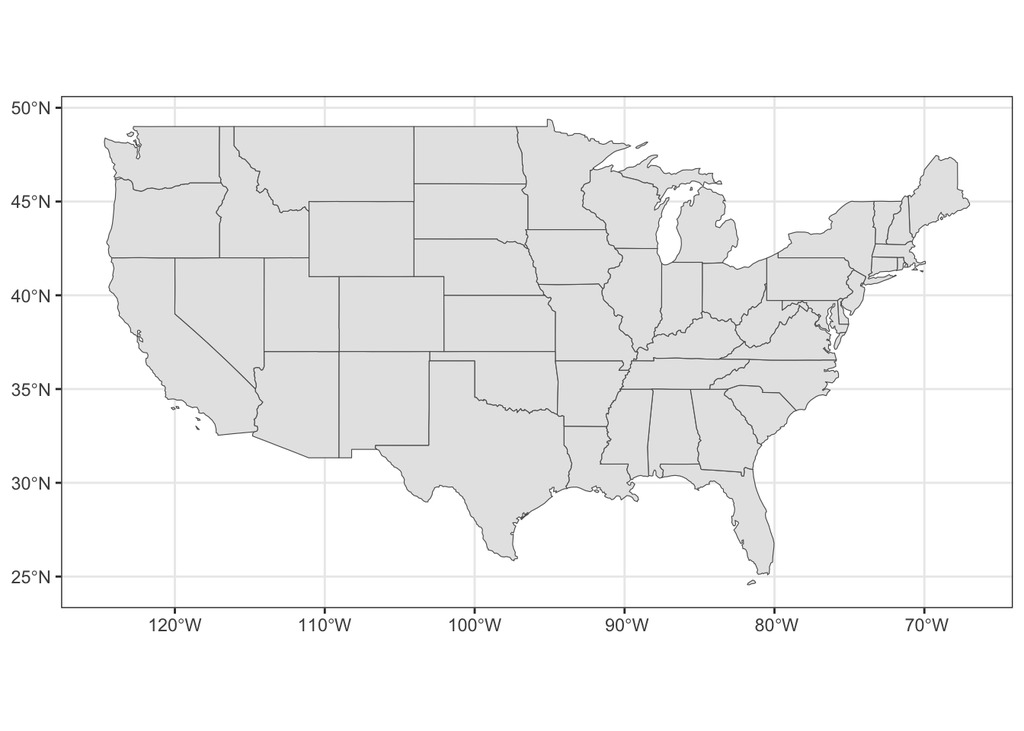

```r
states %>%
  ggplot() +
  geom_sf() +
  theme_bw()
```

Have a look at the **graticule**, the grid of longitude and latitude lines. Ten degrees of longitude spans the same width on the page along the Canadian border as along the Gulf coast. On Earth, that span is shorter along the Canadian border, so the northern states are stretched east to west on this map.

How does *sf* measure a curved surface?

By default, *sf* uses the S2 geometry library for many operations on longitude/latitude data. S2 models the Earth as a sphere, where the shortest path follows an arc of a **great circle**. This accounts for curvature, but a sphere is still an approximation of the Earth. We can also use ellipsoidal methods when we need that additional precision.

## Projected coordinate reference systems

There are also trade-offs associated with projected coordinate systems. Flattening the Earth makes planar calculations possible, but introduces distortion. Depending on the operation and data, planar calculations can be faster than spherical ones. Speed alone is not a reason to choose a CRS.

Different projections preserve different properties. An equal-area projection preserves relative areas, while a conformal projection preserves local angles and shapes. No projection preserves area, shape, distance, and direction everywhere! We will use those trade-offs to choose a CRS below.

Let’s map `states` in EPSG 5070, an equal-area projection built for the conterminous United States:

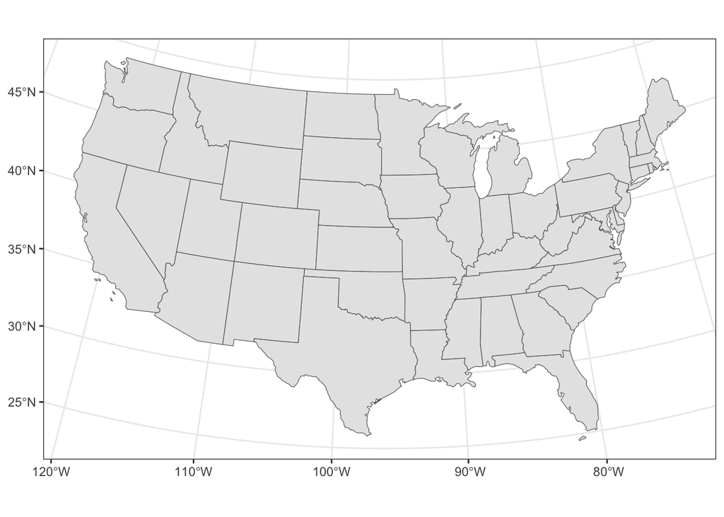

```r
states %>%
  st_transform(crs = 5070) %>%
  ggplot() +
  geom_sf() +
  theme_bw()
```

The parallels now curve and the meridians converge. This is how the graticule appears in this Albers projection, not a test for whether any map is equal-area. Compare the shape of Montana between the two maps. In this projection, the areas of the states are drawn in accurate proportion to one another (i.e., the map is equal-area).

Check your understanding

True or false: An equal-area projection also preserves every distance on the map.

Which is an advantage of a suitable projected CRS for local planar operations?

Coordinates are in linear units on a flat grid, with small distortion over the study area The results are always more accurate Every operation uses less time and memory Projected data do not require a datum

## Transform data to another CRS

Recall that `st_transform()` recalculates coordinates using an EPSG code or `st_crs()` of an object whose CRS we want to match. Let’s compare the coordinates of `sites` before and after transformation.

Our metadata states that the site locations were recorded in EPSG 4326, so we supply that CRS to `st_as_sf()`:

```r
sites_sf <-
  sites %>%
  st_as_sf(
    coords = c("lon", "lat"),
    crs = 4326
  )

sites_sf
```

```
Simple feature collection with 53 features and 1 field
Geometry type: POINT
Dimension:     XY
Bounding box:  xmin: -77.41811 ymin: 38.70396 xmax: -76.46311 ymax: 39.33499
Geodetic CRS:  WGS 84
# A tibble: 53 × 2
   site                     geometry
 * <chr>                 <POINT [°]>
 1 apple         (-76.9542 39.00647)
 2 apricot      (-76.46311 39.11312)
 3 avocado      (-76.79467 38.97405)
 4 banana        (-77.00451 38.9757)
 5 bell pepper  (-76.54802 39.12666)
 6 bilberry     (-77.05334 38.90006)
 7 blackberry   (-76.48502 38.96257)
 8 blackcurrant (-77.26438 38.74157)
 9 blood orange (-77.41811 38.86516)
10 blueberry    (-76.92879 39.06237)
# ℹ 43 more rows
```

The geometry column contains longitude and latitude values in decimal degrees. Now let’s transform the object to the CRS of `census`:

```r
sites_sf %>%
  st_transform(
    st_crs(census)
  )
```

```
Simple feature collection with 53 features and 1 field
Geometry type: POINT
Dimension:     XY
Bounding box:  xmin: 290201 ymin: 4285044 xmax: 373506 ymax: 4355528
Projected CRS: WGS 84 / UTM zone 18N
# A tibble: 53 × 2
   site                 geometry
 * <chr>             <POINT [m]>
 1 apple        (330791 4319311)
 2 apricot      (373506 4330349)
 3 avocado      (344534 4315429)
 4 banana       (326359 4315991)
 5 bell pepper  (366190 4331973)
 6 bilberry     (321940 4307690)
 7 blackberry   (371339 4313671)
 8 blackcurrant (303201 4290533)
 9 blood orange (290201 4304592)
10 blueberry    (333123 4325468)
# ℹ 43 more rows
```

The site `apple` is in the same location in both printouts. Its coordinates changed from degrees of longitude and latitude to meters of easting and northing.

### Transforming is not assigning

The `crs =` argument of `st_as_sf()` does not transform coordinates. It assigns a CRS to values that do not yet have one, and the values themselves are unchanged. Notice what happens when we assign the wrong CRS at the point of conversion:

```r
sites %>%
  st_as_sf(
    coords = c("lon", "lat"),
    crs = 32618
  )
```

```
Simple feature collection with 53 features and 1 field
Geometry type: POINT
Dimension:     XY
Bounding box:  xmin: -77.41811 ymin: 38.70396 xmax: -76.46311 ymax: 39.33499
Projected CRS: WGS 84 / UTM zone 18N
# A tibble: 53 × 2
   site                     geometry
 * <chr>                 <POINT [m]>
 1 apple         (-76.9542 39.00647)
 2 apricot      (-76.46311 39.11312)
 3 avocado      (-76.79467 38.97405)
 4 banana        (-77.00451 38.9757)
 5 bell pepper  (-76.54802 39.12666)
 6 bilberry     (-77.05334 38.90006)
 7 blackberry   (-76.48502 38.96257)
 8 blackcurrant (-77.26438 38.74157)
 9 blood orange (-77.41811 38.86516)
10 blueberry    (-76.92879 39.06237)
# ℹ 43 more rows
```

The metadata now reports a projected CRS, but the coordinate values are unchanged. The easting -76.95 is interpreted in meters rather than degrees of longitude. The object is in the wrong place, even though the conversion ran without an error!

Convert tabular data with the CRS in which the data were recorded!

It is super, super, super important that tabular data are converted to sf objects using the same CRS in which the data were recorded. Any transformation of the coordinates has to come after the data are read in!

## Choose a CRS

One of the most common questions I am asked when assisting colleagues and students with their spatial data is “*which CRS should I choose?*” This is a reasonable question, because the number of choices can be overwhelming (you can see suggested coordinate systems for your study area at [this website](https://jjimenezshaw.github.io/crs-explorer/)). Regardless of which CRS you choose, it is important not to get “stuck” in one projected or geodetic CRS. Each comes with trade-offs, and the task at hand determines which CRS is appropriate.

### Choosing a CRS for a map

For a local map, a suitable local projected CRS, such as the appropriate UTM zone, is often a good starting point. Longitude/latitude displays can also be useful, but a small extent alone does not guarantee little distortion, especially near the poles. For a regional map, choose a projection designed for that region and the property you want to show. EPSG 5070 is useful when relative area matters across the conterminous United States.

### Choosing a CRS for a measurement

For planar measurements, choose a projection that preserves the property you need:

- Comparing or summing **areas** calls for an equal-area projection
- Measuring **distances** requires checking which distances are preserved. An azimuthal equidistant projection preserves distances from its center, not between every pair of locations. A suitable UTM CRS is often useful for approximate local distances
- Preserving local **angles and shapes** calls for a conformal projection
- Preserving **directions from a chosen center** calls for an azimuthal projection.

For distances across a large region, consider a **geodesic** method on geographic data. These methods measure along the curved surface. Choose the measurement method along with the CRS.

*Note: We will begin measuring distances and areas in R in* **3.6 Geometric operations with sf***.*

### Choosing a CRS for spatial operations

When an operation depends on planar units, such as the distance, area, and buffer calculations in *3.6 Geometric operations with sf*, use a projected CRS that is appropriate for the task and spatial extent. After identifying suitable CRSs, the number and complexity of the geometries can help determine which object is more efficient to transform (see *3.2 Introduction to spatial vector data*).

### Choosing a CRS for a small spatial extent

The **Universal Transverse Mercator** (UTM) system divides the Earth into 60 zones, generally 6° wide in longitude, each with a central meridian. UTM is conformal and keeps distortion small within an appropriate zone. For a city or county, this can be a great starting point. See the [PROJ guide to UTM](https://proj.org/en/stable/operations/projections/utm.html) for the zone layout.

Check that the UTM zone suits your study area!

Choose a UTM zone that suits your study area. Distortion increases away from its central meridian, so do not assume that one zone is suitable for a study spanning several zones. Crossing a zone boundary does not suddenly make the data unusable.

UTM coordinates are **eastings** (X) and **northings** (Y), measured in meters. The **false easting** and **false northing** are offsets built into the CRS, not the coordinate values themselves:

- The central meridian has an easting of **500,000 meters**. A point 100 grid meters east of it has an easting of 500,100 meters.
- In the Northern Hemisphere, northing is zero at the equator and increases northward. In the Southern Hemisphere, a false northing of **10,000,000 meters** is assigned at the equator, with values decreasing southward.

These offsets keep coordinates positive within the intended zone. They do not remove projection distortion.

Eastings and northings can be handy in the field!

If I am attempting to locate a set of coordinates and my GPS unit is set to degrees, the target coordinates indicate the direction to travel, but not the distance. With my GPS unit set to the same UTM CRS as the target coordinates, the difference between my coordinates and the target is an approximate distance in meters along each of the grid’s axes!

Probably the biggest challenge associated with using a UTM CRS is choosing the zone, hemisphere, and datum. The District of Columbia lies near 77°W, within zone 18 (78°W to 72°W). It is north of the equator, so we need a Northern Hemisphere CRS.

Luckily, the authors of our textbook provide [a handy function](https://r.geocompx.org/reproj-geo-data.html#which-crs), `lonlat_to_utm()`, to find a **WGS 84 UTM EPSG code** from a longitude/latitude pair. Our copy is in `source_script_module_3.R`, so it is already available. Let’s try it for DC:

```r
lonlat_to_utm(
  c(-77, 38)
)
```

```
[1] 32618
```

This returns 32618, the EPSG code assigned to `census`. With the same longitude south of the equator, the WGS 84 code would be 32718. Other datums have different EPSG codes for the same zone. Our helper uses the regular six-degree zones, so verify its suggestion for locations near the antimeridian or in the exceptional zones around Norway and Svalbard. Polar regions need a different system.

Now compare the appearance of DC in two projected CRSs. First, let’s use Conus Albers (EPSG 5070):

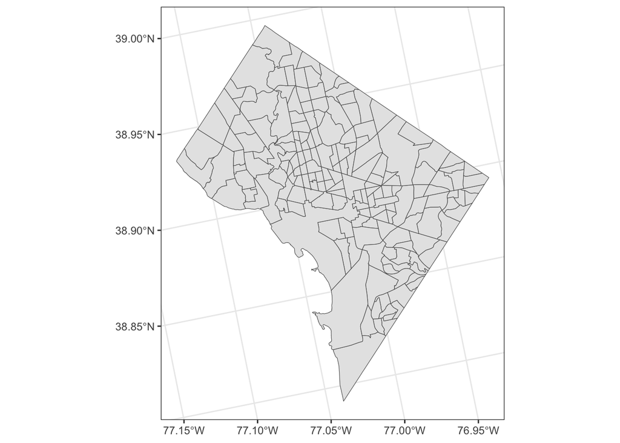

```r
census %>%
  st_transform(crs = 5070) %>%
  ggplot() +
  geom_sf() +
  theme_bw()
```

The graticule’s longitude lines tilt across this map rather than running vertically, because the city sits far from the longitude on which this projection is centered. In the UTM CRS assigned to the object, the longitude lines run nearly vertical:

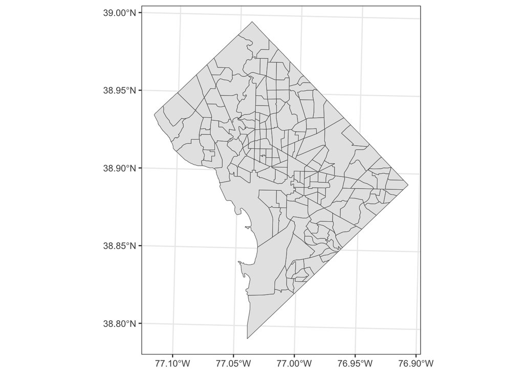

```r
census %>%
  ggplot() +
  geom_sf() +
  theme_bw()
```

Here, UTM keeps local distortion small and the longitude lines nearly vertical. The tilt in the Albers map is not, by itself, evidence of inaccurate areas or distances.

Now you!

The bounding box of `sites_sf` spans longitudes of roughly -77.4 to -76.5. Determine the UTM zone of the sites and the EPSG code of its WGS 84 Northern Hemisphere CRS.

*Hint: Supply `lonlat_to_utm()` with a representative longitude/latitude pair. Then check the CRS name with `st_crs()` and `$Name`.*

Click here to see my answer

```r
# Determine the EPSG code for the WGS 84 UTM CRS:

lonlat_to_utm(
  c(-77, 39)
)
```

```
[1] 32618
```

```r
st_crs(32618)$Name
```

```
[1] "WGS 84 / UTM zone 18N"
```

The sites are in UTM zone 18N. EPSG 32618 identifies WGS 84 / UTM zone 18N. The zone alone does not specify the datum. Because the sites span a small spatial extent within a single UTM zone, this is an appropriate CRS for mapping the sites or measuring the distances between them.

## Putting it all together

At this point, my hope is that you have a mental model for what a CRS is and how to work with one. Choosing a CRS for a task might look something like this (click to expand):

[figure not shown]

**Note**

This tree is a visualization of *my* mental model for this process. It is totally okay if your model differs! What is important is that you have a *working* model, a system in place that allows you to retrieve the tools that you need to solve a problem.

## Take-home points

- A **coordinate reference system** locates a geometry on Earth using a datum, a coordinate system with defined units, and, for projected CRSs, a projection.
- The **geographic** CRSs used here record longitude and latitude in angular units and are labeled **geodetic** by *sf*. A **projected** CRS records locations on a flat grid in linear units, typically meters.
- Use `st_crs()` to read the **well-known text** description of a CRS. Check its datum, units, projection (if present), and area of use.
- `st_transform()` recalculates coordinates. The `crs =` argument of `st_as_sf()` assigns a CRS without changing coordinate values. Supply the CRS in which the data were recorded.
- No projection preserves area, shape, distance, and direction everywhere. Equal-area projections preserve area, conformal projections preserve local angles, and equidistant and azimuthal projections preserve specified distances and directions. Check which ones!
- Use a suitable projected CRS when an operation depends on planar units. Choose the CRS based on the task and spatial extent before considering the cost of transforming each object.
- A suitable UTM CRS keeps distortion small at local extents. Its coordinates are eastings and northings in meters, and the full CRS also specifies a datum and hemisphere.

## Exercises

Test your knowledge!

1. In the WKT of a projected CRS, which section describes the projection and its parameters?

   BASEGEOGCRS CONVERSION DATUM USAGE
2. True or false: `st_transform()` and the `crs =` argument of `st_as_sf()` both recalculate the coordinate values of an object.
3. A colleague recorded animal locations with a GPS unit set to EPSG 4326 and would like to analyze them in EPSG 32618. Which sequence of operations produces a correct simple features object?

   Convert the data with st_as_sf(), supplying crs = 4326, then transform the object with st_transform(), supplying crs = 32618 Convert the data with st_as_sf(), supplying crs = 32618 Convert the data with st_as_sf(), supplying crs = 32618, then transform the object with st_transform(), supplying crs = 4326 Transform the data frame with st_transform(), supplying crs = 32618, then convert it with st_as_sf()
4. You want to compare the areas of protected lands across the conterminous United States. Which kind of projection minimizes distortion for this task?

   A conformal projection An equal-area projection An equidistant projection An azimuthal projection
5. Match each task to a suitable CRS.
6. Two simple features objects are assigned different coordinate reference systems. Why can their coordinate values not be compared directly?

   The same coordinate values describe different locations in different reference systems Objects with different CRSs cannot be printed together A geodetic CRS contains no coordinate values Coordinate values can only be compared when both objects are geodetic

## Reference

- **Code section**: A portion of an R script file that is delineated by a section header.
- **Coordinate reference system**: The reference system (may be projected or geographic) that allows us to define the location of a geometry on the surface of the Earth.
- **Datum**: The model used to represent the Earth’s surface.
- **Easting**: The X coordinate of a projected coordinate reference system, measured in linear units from the system’s origin.
- **False eastings**: The location of a coordinate, in meters, relative to the central meridian of a UTM zone.
- **False northings**: The distance of a coordinate from the equator, in meters, within a UTM coordinate reference system.
- **Geodesic**: A measurement made along the curved surface of the Earth rather than on a flat plane.
- **Geodetic**: An unprojected coordinate reference system where locations are expressed in angular units, usually decimal degrees.
- **Global environment**: A workspace that provides a reference point for all user-assigned objects associated with the current session.
- **Graticule**: The grid of longitude and latitude lines drawn on a map.
- **Great circle**: A circle on the surface of a sphere whose plane passes through the center of the sphere. The shortest path between two points on a sphere follows an arc of a great circle.
- **Northing**: The Y coordinate of a projected coordinate reference system, measured in linear units from the system’s origin.
- **Prime meridian**: The location of 0 degrees longitude.
- **Projection**: A model used to transform data and the coordinate system on a flat surface.
- **Session history**: All lines of code that have been sent to R since the beginning of a session (or since the session history was last cleared).
- **Universal Transverse Mercator**: A common class of projected coordinate reference systems used primarily for relative small areas (e.g., for a given city).
- **Well-known text**: A markup language that is the international standard for representing coordinate reference systems and geometries.
- **Workspace pane**: A pane of RStudio used to view/manage objects in your global environment and your session history.

**Important!** Primitive functions, as well as functions in the packages that R attaches by default (e.g., *base*, *utils*, *stats*, and *graphics*), are available as soon as you start an R session.

[output not shown]

The most common keyboard shortcuts are provided below for Windows and Mac operating systems.

| Task | Windows | Mac |
| --- | --- | --- |
| View all keyboard shortcuts | Alt + ⇧ + K | ⌥ + ⇧ + K |
| Open an existing script | Ctrl + O | ⌘ + O |
| Create a new script | Ctrl + ⇧ + N | ⌘ + ⇧ + N |
| Save script file | Ctrl + S | ⌘ + S |
| Execute code | Ctrl + Enter | ⌘ + Return |
| Copy | Ctrl + C | ⌘ + C |
| Paste | Ctrl + V | ⌘ + V |
| Add a pipe operator | Ctrl + ⇧ + M | ⌘ + ⇧ + M |
| Add an assignment operator | Alt + dash | ⌥ + dash |
| Add a new code section | Ctrl + ⇧ + R | ⌘ + ⇧ + R |
| Indent code | Ctrl + I | ⌘ + I |